# Traffic Incident Reports in School Zone Beacons

Akul Saxena

## Introduction

This project will explore the effect of school zone beacons on the incidence of traffic reports in the City of Austin. This analysis will be conducted using two datasets sourced from the [City of Austin’s open data portal](https://data.austintexas.gov/), namely the [School Zone Beacons](https://data.austintexas.gov/Transportation-and-Mobility/School-Zone-Beacons/v6kq-45cf) and [Real-Time Traffic Incident Report](https://data.austintexas.gov/Transportation-and-Mobility/Real-Time-Traffic-Incident-Reports/dx9v-zd7x) datasets. The school zone beacons dataset contains information on the locations and attributes (sign height, power source, pole width, etc.) of all school zone flasher signals in the city of Austin, with each row representing a specific flasher. The traffic incident report dataset contains traffic incident information from the [Austin-Travis County traffic reports RSS feed](https://www.austintexas.gov/qact/default.cfm). Each row in this dataset represents a traffic incident, the type of incident it was, and where the incident occurred. The linking variable between these two datasets is latitude and longitude in degrees. I expect to see a decrease in traffic incidents in areas surrounding school zone flashers. As a research question, this can be more formally stated as: does the presence of school zone flashers lead to a decrease in traffic incidents?

```r
school_zone_data <- read.csv("C:/Users/Saxen/Downloads/School_Zone_Beacons.csv")
traffic_data <- read.csv("C:/Users/Saxen/Downloads/Real-Time_Traffic_Incident_Reports.csv")
head(school_zone_data)
```

```
##     beacon_id        zone_name zone_status zone_id station_id clock
## 1 7122-172-00           AUSTIN      Active    7122        172  True
## 2 7505-276-00         WESTLAKE      Active    7505        276  True
## 3 7111-150-01      OAK SPRINGS      Active    7111        150 False
## 4 7405-012-00 WESTVIEW, PARMER      Active    7405        012  True
## 5 7304-176-00   TRAVIS HEIGHTS      Active    7304        176  True
## 6 7103-130-01           MARTIN      Active    7103        130 False
##   sub_station_id direction height_inches pole_type power_feed mount_location
## 1              0        EB            NA
## 2              0        WB         113.0      4_IN         UG
## 3              1        SB          86.0      2_IN         OH
## 4              0        EB         113.0      4_IN         UG
## 5              0        EB          94.5      4_IN         OH
## 6              1        NB          91.0      4_IN         OH
##   power_source atd_location_id           created_date created_by
```

[output cut: 27 more lines]

```r
head(traffic_data)
```

```
##                                     Traffic.Report.ID
## 1 C163BCD1CF90C984E9EDA4DBA311BCA369A7D1A1_1528871759
## 2 6B20382196FB454E9FD06A33E60142902A2F0706_1528884936
## 3 2A7A84FC69D56A2C379C274D2F0831442D3E7B8E_1587158703
## 4 89D3B75BB5932F10D25B5852A9902DA26C3DF11A_1587159652
## 5 E7F9EFF0E81057A5C8FE41CABE4D9C6EEA82DAA0_1587157255
## 6 5E777B99E8FD7269347B6E0FC10C15797B83CF22_1587159879
##                 Published.Date Issue.Reported               Location Latitude
## 1 06/13/2018 06:35:59 AM +0000  Crash Service (30.283797,-97.741906) 30.28380
## 2 06/13/2018 10:15:36 AM +0000 Traffic Hazard (30.339593,-97.700963) 30.33959
## 3 04/17/2020 09:25:03 PM +0000   Crash Urgent (30.329455,-97.638105) 30.32945
## 4 04/17/2020 09:40:52 PM +0000 Traffic Hazard (30.202806,-97.760701) 30.20281
## 5 04/17/2020 09:00:55 PM +0000   Crash Urgent (30.184265,-97.687339) 30.18426
## 6 04/17/2020 09:44:39 PM +0000   Crash Urgent (30.353742,-97.690482) 30.35374
##   Longitude                                     Address   Status
## 1 -97.74191                    W 21ST ST & GUADALUPE ST ARCHIVED
## 2 -97.70096                    400-717 E ANDERSON LN EB ARCHIVED
## 3 -97.63810 E US 290 HWY SVRD EB & EASTERN HEIGHTS BLVD ARCHIVED
## 4 -97.76070                         5300-blk S Ih 35 Sb ARCHIVED
## 5 -97.68734                   4500-4720 S Us 183 Hwy Sb ARCHIVED
## 6 -97.69048                        9001 N Ih 35 Svrd Nb ARCHIVED
##                    Status.Date
## 1 06/13/2018 09:00:03 AM +0000
## 2 06/13/2018 11:20:03 AM +0000
## 3 04/17/2020 09:55:03 PM +0000
## 4 04/17/2020 09:55:03 PM +0000
## 5 04/17/2020 11:30:04 PM +0000
## 6 04/18/2020 12:05:28 AM +0000
```

# Tidying

```r
# we will use ggplot::geom_bin2d to spatially bin the traffic incidents
viz <- traffic_data |>
        # remove NAs
        drop_na(Longitude) |>
        drop_na(Latitude) |>
        # remove locations outside of Travis County
        filter(Longitude < -94 & Longitude > -106) |>
        filter(Latitude > 26 & Latitude < 38) |>
        ggplot(aes(Longitude, Latitude)) +
                geom_bin2d(bins=1000) +
                scale_fill_gradientn(colors = heat.colors(100))
# store ggplot visualization data
bindata <- layer_data(viz, i=1)
# example of 10 random rows from bindata
bindata |> select(xmin, xmax, ymin, ymax, count, fill) |> sample_n(10)
```

```
##         xmin      xmax     ymin     ymax count    fill
## 1  -97.77975 -97.77805 30.24587 30.24694    59 #FF1600
## 2  -97.70635 -97.70464 30.30925 30.31033     2 #FF0000
## 3  -97.87365 -97.87194 30.44032 30.44139     3 #FF0100
## 4  -97.79170 -97.79000 30.15993 30.16100     9 #FF0300
## 5  -97.72000 -97.71830 30.42743 30.42850     9 #FF0300
## 6  -97.77293 -97.77122 30.48866 30.48974     3 #FF0100
## 7  -97.91803 -97.91633 30.18786 30.18893     3 #FF0100
## 8  -97.95730 -97.95559 30.47577 30.47685    12 #FF0400
## 9  -97.72000 -97.71830 30.48007 30.48114     1 #FF0000
## 10 -97.69952 -97.69781 30.30496 30.30603     2 #FF0000
```

# Joining / Merging

We will now join the two datasets. The general approach will be as follows: 1) Iterate through all school zone flashers and determine whether it lies within an incident zone (defined as bin with >34 incidents); 2) Remove all flashers outside of an incident zone; 3) Perform `_join` operations on the remaining flashers with the binned data from before. After running this procedure, the number of rows remaining in the school zone dataset dropped from 561 to 52 rows.

```r
df <- bindata |> filter(count>34)
# function to check whether a flasher lies within an incident zone
inBetween <- function(lon, lat) {
        xmin = df[which.min(abs(lon-df$x)),]$xmin
        xmax = df[which.min(abs(lon-df$x)),]$xmax
        ymin = df[which.min(abs(lat-df$y)),]$ymin
        ymax = df[which.min(abs(lat-df$y)),]$ymax
        if (lon > xmin & lon < xmax & lat > ymin & lat < ymax) { return(TRUE) }
        return(FALSE)
}
# prep flashers dataset for merge with binned incident dataset
prepped_sz_df <- school_zone_data |>
        # keep height and pole type for later analysis
        select(zone_name, height_inches, pole_type, longitude, latitude) |>
        # iterate and classify flashers as in/outside of high-incident zone
        rowwise() |>
        mutate(inBtwn = case_when(inBetween(longitude, latitude) ~ 'Y')) |>
                filter(inBtwn=='Y') |>
        # from remaining flashers, add xbin and ybin to prepare for join
        mutate(xbin = bindata[which.min(abs(longitude-bindata$x)),]$xbin,
               ybin = bindata[which.min(abs(latitude-bindata$y)),]$ybin)
# number of rows pre-merge
cat('Pre-merge: School Zone Dataset -', nrow(prepped_sz_df), 'rows; Binned Traffic Incident Dataset -', nrow(df), ' rows\n')
```

```
## Pre-merge: School Zone Dataset - 561 rows; Binned Traffic Incident Dataset - 2135  rows
```

```r
# list records with IDs not appearing in both datasets
prepped_sz_df |>
        anti_join(df, by=c("xbin","ybin"))
```

```
## # A tibble: 509 × 8
## # Rowwise:
##    zone_name        height_inches pole_type longitude latit…¹ inBtwn  xbin  ybin
##    <chr>                    <dbl> <chr>         <dbl>   <dbl> <chr>  <int> <int>
##  1 AUSTIN                    NA   ""            -97.8    30.3 Y        617   255
##  2 WESTLAKE                 113   "4_IN"        -97.8    30.3 Y        589   254
##  3 OAK SPRINGS               86   "2_IN"        -97.7    30.3 Y        652   252
##  4 WESTVIEW, PARMER         113   "4_IN"        -97.7    30.4 Y        659   385
##  5 TRAVIS HEIGHTS            94.5 "4_IN"        -97.7    30.2 Y        628   226
##  6 MARTIN                    91   "4_IN"        -97.7    30.3 Y        637   233
##  7 PILLOW                    85   "2_IN"        -97.7    30.4 Y        636   342
##  8 BLUEBONNET TRAIL          90   "4_IN"        -97.6    30.4 Y        705   326
##  9 METZ                      82   "2_IN"        -97.7    30.3 Y        643   236
## 10 MILLS                    104   "4_IN"        -97.9    30.2 Y        551   196
## # … with 499 more rows, and abbreviated variable name ¹latitude
```

```r
# list records with identical IDs
joined_df <- prepped_sz_df |>
        inner_join(df, by=c("xbin","ybin")) |>
        # strip extraneous variables
        select(zone_name, height_inches, pole_type, longitude, latitude, xbin, ybin, count)
joined_df
```

```
## # A tibble: 52 × 8
## # Rowwise:
##    zone_name       height_inches pole_type longitude latitude  xbin  ybin count
##    <chr>                   <dbl> <chr>         <dbl>    <dbl> <int> <int> <dbl>
##  1 KOCUREK                  81.5 "4_IN"        -97.8     30.2   577   163    60
##  2 GOVALLE                  83   "4_IN"        -97.7     30.3   657   250    36
##  3 BLACKSHEAR               98   "4_IN"        -97.7     30.3   644   250    49
##  4 ALLISON                  98.5 "2_IN"        -97.7     30.2   658   220    55
##  5 PLEASANT HILL           100   "4_IN"        -97.8     30.2   608   179    39
##  6 ST IGNATIUS              84   "4_IN"        -97.8     30.2   624   221   279
##  7 PECAN SPRINGS            NA   ""            -97.7     30.3   673   285    43
##  8 CROCKETT                 86   "2_IN"        -97.8     30.2   598   199   141
##  9 DAWSON                   NA   ""            -97.8     30.2   617   216    43
## 10 ST LOUIS SCHOOL          90   "2_IN"        -97.7     30.4   636   326    64
## # … with 42 more rows
```

```r
cat('Post-merge:', nrow(joined_df), 'rows')
```

```
## Post-merge: 52 rows
```

# Wrangling

```r
# clean up pole_types column
joined_df <- joined_df |> mutate(pole_type = recode(na_if(pole_type, ""), .missing = "Missing"))
# Which school zones had the most flashers in incident zones?
joined_df |>
        group_by(zone_name) |>
        summarize(n=n()) |>
        arrange(desc(n))
```

```
## # A tibble: 34 × 2
##    zone_name         n
##    <chr>         <int>
##  1 PLEASANT HILL     5
##  2 DAWSON            4
##  3 BEDICHEK          3
##  4 HARRIS            2
##  5 JORDAN            2
##  6 JOSLIN            2
##  7 KOCUREK           2
##  8 REAGAN            2
##  9 RIDGETOP          2
## 10 SANCHEZ           2
## # … with 24 more rows
```

```r
# What is the distribution of pole types in incident zones?
joined_df |>
        group_by(pole_type) |>
        summarize(n=n())
```

```
## # A tibble: 3 × 2
##   pole_type     n
##   <chr>     <int>
## 1 2_IN         18
## 2 4_IN         20
## 3 Missing      14
```

```r
# Which school zones had the highest mean incident count?
joined_df |>
        select(zone_name, count) |>
        group_by(zone_name) |>
        summarize(mean_count = mean(count)) |>
        arrange(desc(mean_count))
```

```
## # A tibble: 34 × 2
##    zone_name                  mean_count
##    <chr>                           <dbl>
##  1 ST IGNATIUS                      279
##  2 RIDGETOP                         155
##  3 BEDICHEK                         145
##  4 CROCKETT                         141
##  5 SANCHEZ                          138
##  6 JORDAN                           118.
##  7 JOSLIN                           118.
##  8 WILLIAMS                         112
##  9 ST. MARTIN LUTHERAN SCHOOL       102
## 10 STEINER RANCH                     93
## # … with 24 more rows
```

```r
# Get summary statistics of incident counts and, using that information,
# classify zones as LOW, MEDIUM, or HIGH incident zones
summary(joined_df$count)
```

```
##    Min. 1st Qu.  Median    Mean 3rd Qu.    Max.
##   35.00   44.75   62.00   83.35   99.00  310.00
```

```r
joined_df <- joined_df |> mutate(count_desc = case_when(count < 45 ~ 'LOW',
                                                        count < 90 ~ 'MEDIUM',
                                                        .default = 'HIGH'))
joined_df
```

```
## # A tibble: 52 × 9
## # Rowwise:
##    zone_name       height_in…¹ pole_…² longi…³ latit…⁴  xbin  ybin count count…⁵
##    <chr>                 <dbl> <chr>     <dbl>   <dbl> <int> <int> <dbl> <chr>
##  1 KOCUREK                81.5 4_IN      -97.8    30.2   577   163    60 MEDIUM
##  2 GOVALLE                83   4_IN      -97.7    30.3   657   250    36 LOW
##  3 BLACKSHEAR             98   4_IN      -97.7    30.3   644   250    49 MEDIUM
##  4 ALLISON                98.5 2_IN      -97.7    30.2   658   220    55 MEDIUM
##  5 PLEASANT HILL         100   4_IN      -97.8    30.2   608   179    39 LOW
##  6 ST IGNATIUS            84   4_IN      -97.8    30.2   624   221   279 HIGH
##  7 PECAN SPRINGS          NA   Missing   -97.7    30.3   673   285    43 LOW
##  8 CROCKETT               86   2_IN      -97.8    30.2   598   199   141 HIGH
##  9 DAWSON                 NA   Missing   -97.8    30.2   617   216    43 LOW
## 10 ST LOUIS SCHOOL        90   2_IN      -97.7    30.4   636   326    64 MEDIUM
## # … with 42 more rows, and abbreviated variable names ¹height_inches,
## #   ²pole_type, ³longitude, ⁴latitude, ⁵count_desc
```

```r
# Get summary statistics for school zone sign heights
summary(joined_df$height_inches)
```

```
##    Min. 1st Qu.  Median    Mean 3rd Qu.    Max.    NA's
##   76.00   84.00   90.00   92.57   98.00  125.00      15
```

```r
# Get summary statistics for pole types
# frequency of pole types
table(joined_df$pole_type)
```

```
##
##    2_IN    4_IN Missing
##      18      20      14
```

```r
# proportions of each pole type
prop.table(table(joined_df$pole_type))
```

```
##
##      2_IN      4_IN   Missing
## 0.3461538 0.3846154 0.2692308
```

```r
# cross classification table of school zones and pole types
table(joined_df$zone_name, joined_df$pole_type)
```

```
##
##                                 2_IN 4_IN Missing
##   ALLISON                          1    0       0
##   BARRINGTON                       1    0       0
##   BEDICHEK                         3    0       0
##   BLACKSHEAR                       0    1       0
##   BRYKER WOODS                     1    0       0
##   CASEY                            0    0       1
##   COVINGTON                        0    1       0
##   CROCKETT                         1    0       0
##   CUNNINGHAM, EDEN PARK ACADEMY    0    1       0
##   DAWSON                           2    0       2
##   GOVALLE                          0    1       0
##   GRAHAM                           1    0       0
##   HARRIS                           0    1       1
##   JORDAN                           0    0       2
##   JOSLIN                           1    1       0
##   KOCUREK                          0    2       0
##   MCBEE                            0    1       0
##   PECAN SPRINGS                    0    0       1
##   PLEASANT HILL                    1    3       1
##   REAGAN                           0    1       1
##   RIDGETOP                         0    1       1
##   SANCHEZ                          1    1       0
##   SIMS                             1    1       0
##   SPICEWOOD                        1    0       0
##   ST ELMO                          1    0       0
##   ST IGNATIUS                      0    1       0
##   ST LOUIS SCHOOL                  1    0       0
##   ST. MARTIN LUTHERAN SCHOOL       0    1       0
##   STEINER RANCH                    0    1       0
##   TRAVIS                           0    0       1
##   WALNUT CREEK                     1    0       0
##   WEBB                             0    0       1
##   WILLIAMS                         0    1       1
##   WOOTEN, REEDEMER                 0    0       1
```

# Visualizations

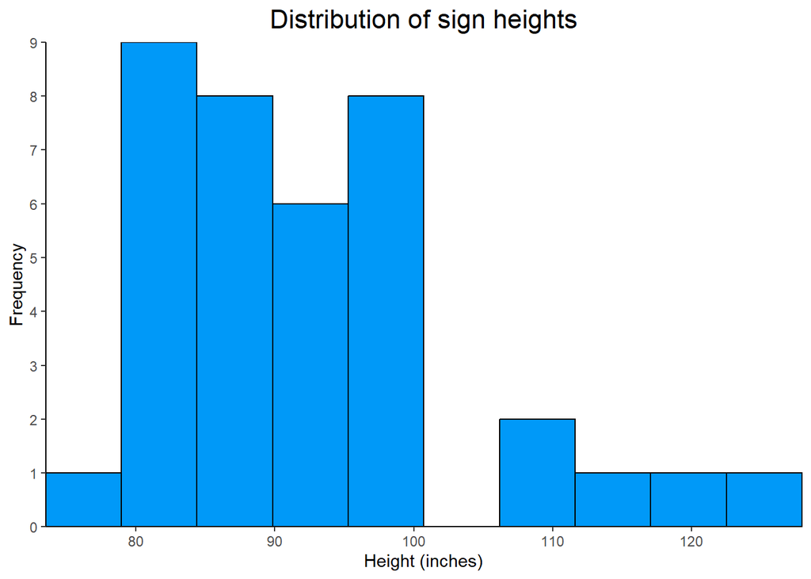

```r
# Distribution of sign heights (1 variable)
joined_df |>
        ggplot(aes(height_inches)) +
                geom_histogram(bins=10, color = "#000000", fill = "#0099F8") +
                labs(title="Distribution of sign heights",
                     x="Height (inches)",
                     y="Frequency") +
                theme_classic() +
                theme(plot.title = element_text(hjust = 0.5, size=16)) +
                scale_x_continuous(expand = c(0, 0)) +
                scale_y_continuous(breaks=0:9, expand = c(0, 0))
```

```r
pal <- colorNumeric(palette=heat.colors(100), domain = bindata$value)
```

This graph plots the distribution of sign heights in incident zones. A majority of the signs are distributed below the 100 inch mark.

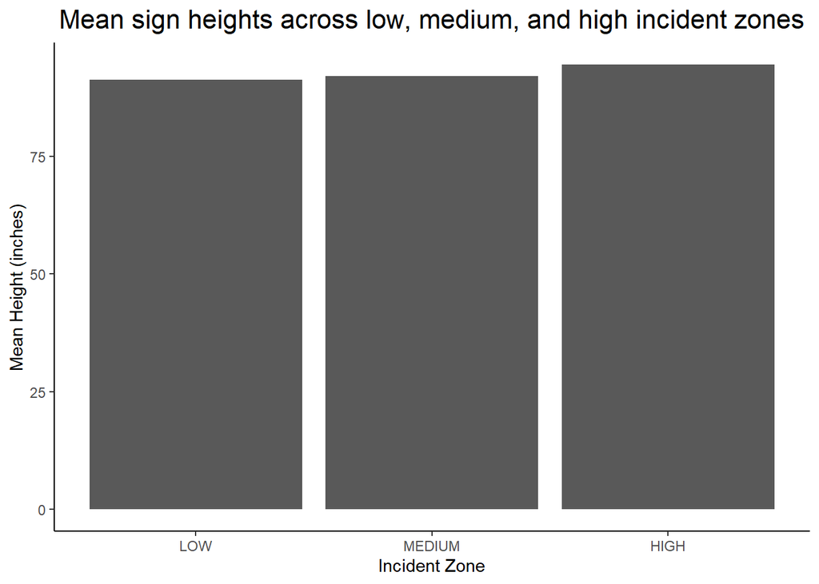

```r
# Mean sign heights across different count descriptions (2 variables + stat function)
joined_df |>
        ggplot(aes(reorder(count_desc, -height_inches), height_inches)) +
        geom_bar(stat='summary', fun='mean') +
        labs(title="Mean sign heights across low, medium, and high incident zones",
             x="Incident Zone",
             y="Mean Height (inches)") +
        theme_classic() +
        theme(plot.title = element_text(hjust = 0.5, size=16)) +
        scale_x_discrete(limits=c("LOW", "MEDIUM", "HIGH"))
```

This graph shows the mean sign heights for low, medium, and high incident zones. Overall, there does not seem to be a trend for average sign heights across the three incident zones. The averages seem to be about the same across all three zone types.

```r
# Visualization of bin locations and school zone sign locations overlaid on map
# of Austin (2 variables)
filtered_bindata <- bindata |> filter(count > 49)
leaflet(filtered_bindata) |> addTiles() |>
        addRectangles(
                lng1 = ~xmax, lat1 = ~ymax,
                lng2 = ~xmin, lat2 = ~ymin,
                fillColor = ~fill,
                label = ~value,
                weight = 1,
                fillOpacity = 0.8) |>
        # add markers showing locations of school zone flashers
        addMarkers(
                lng = school_zone_data$longitude,
                lat = school_zone_data$latitude,
                label = school_zone_data$zone_name) |>
        addLegend(
                "topright",
                pal = pal,
                values = ~value,
                title = "Number of Incidents")
```

[interactive chart not shown]

An interactive html widget (does not show up on pdf) showing the locations of every school zone sign and incident zone overlaid on a map of Austin. A majority of incident zones appear along major thoroughfares, such as interstates, highways, and high-capacity roads. For the most part, nearly all school zone signs are outside of incident zones. The ones that are tend to be closer to the city center.

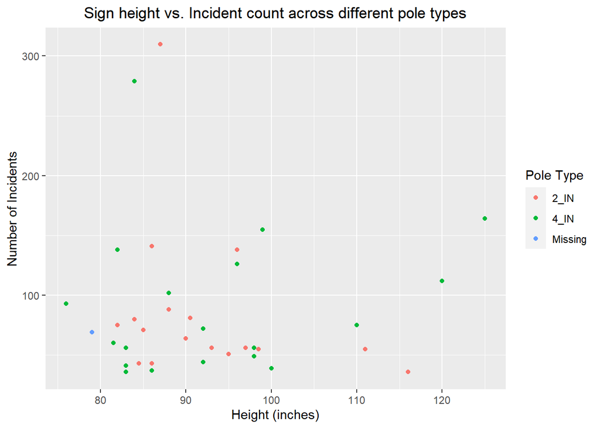

```r
# Visualization of sign heights against incident count for different pole types (3 variables)
joined_df |>
        ggplot(aes(height_inches, count, color=pole_type)) +
                geom_point() +
                labs(x="Height (inches)",
                     y="Number of Incidents",
                     color="Pole Type") +
                ggtitle("Sign height vs. Incident count across different pole types") +
                theme(plot.title = element_text(hjust = 0.5))
```

This scatterplot plots the sign of a school zone height against the number of incidents that took place near it, and is colored by the pole type. There seems to be no relation among the three variables. No clear trend can be discerned from the two plotted variabes, and no pattern can be deduced from the coloration as well.